# Peer assignment

This report aims to identify the most harmful events across all the US, we are going to see which type of events caused more damaged to population’s health and properties. We are using the storm dataset from the National weather service and you can find the dataset documentation here: https://d396qusza40orc.cloudfront.net/repdata%2Fpeer2_doc%2Fpd01016005curr.pdf

## Data Processing

First I have changed the working directory and loaded the tidyverse packages so I can easilly manipulate and plot the data.

```r
setwd("~/Github/DataScienceSpecialization/Reproducible Research/Peer assignment")
library(tidyverse)
```

Then I loaded the data using the read_csv from the readr package and I cached this operations in order to better work later.

```r
    stormdata <- read_csv("repdata-data-StormData.csv")
```

In orther to successfully identify the most harmful events in terms of population health I grouped the stormdata by the type of event variable (EVTYPE) then for each type of event calulated the total fatalities and injuries caused.

Following an invented standart we are going to say that an event is very harmful if it has caused more than 199 deaths and/or more than 599 injuries. So I have created a categorical variable that will have two levels “not that harmful” and “very harmful”.

```r
dataset1 <- group_by(stormdata,EVTYPE) %>% summarize(FATALITIES = sum(FATALITIES),INJURIES = sum(INJURIES)) %>% mutate( health = if_else(FATALITIES >=200 | INJURIES >= 600,"Very Harmful","Not that harmful"))
```

```r
dataset2 <- select(stormdata,EVTYPE,PROPDMG,PROPDMGEXP,CROPDMG,CROPDMGEXP) %>%
    filter(PROPDMG > 0 | CROPDMGEXP > 0) %>%
    mutate(PROPDMGMULT = case_when(
    PROPDMGEXP == "K" ~ 10^3,
    PROPDMGEXP == "M" ~ 10^6,
    PROPDMGEXP == "B" ~ 10^9,
    PROPDMGEXP == "h" ~ 10^2,
    PROPDMGEXP == "m" ~ 10^-3,
    PROPDMGEXP == "2" ~ 2,
    PROPDMGEXP == "3" ~ 3,
    PROPDMGEXP == "4" ~ 4,
    PROPDMGEXP == "5" ~ 5,
    PROPDMGEXP == "6" ~ 6,
    PROPDMGEXP == "7" ~ 7,
    TRUE ~ 1
)) %>%
    mutate(CROPDMGMULT = case_when(
    CROPDMGEXP == "K" ~ 10^3,
    CROPDMGEXP == "M" ~ 10^6,
    CROPDMGEXP == "B" ~ 10^9,
    CROPDMGEXP == "h" ~ 10^2,
    CROPDMGEXP == "m" ~ 10^-3,
    CROPDMGEXP == "2" ~ 2,
    CROPDMGEXP == "k" ~ 10^3,
    TRUE ~ 1
)) %>%
    mutate(PROPDMG = PROPDMG*PROPDMGMULT, CROPDMG = CROPDMG*CROPDMGMULT) %>%
    mutate(TOTALDMG = PROPDMG+CROPDMG) %>%
    select(EVTYPE,PROPDMG,CROPDMG,TOTALDMG) %>%
    arrange(desc(TOTALDMG)) %>%
    mutate( property = if_else(TOTALDMG >=10^9,"Very Harmful","Not that harmful"))
```

## Results

To show your the most harmful type of events for human health, the next plot shows the name of the event as text and its xy coordinates represent the logarithm of the total number of fatalities and injuries caused. In this sense, the most harmful events will be in the upper right corner, in this case a tornado is the most harmful.

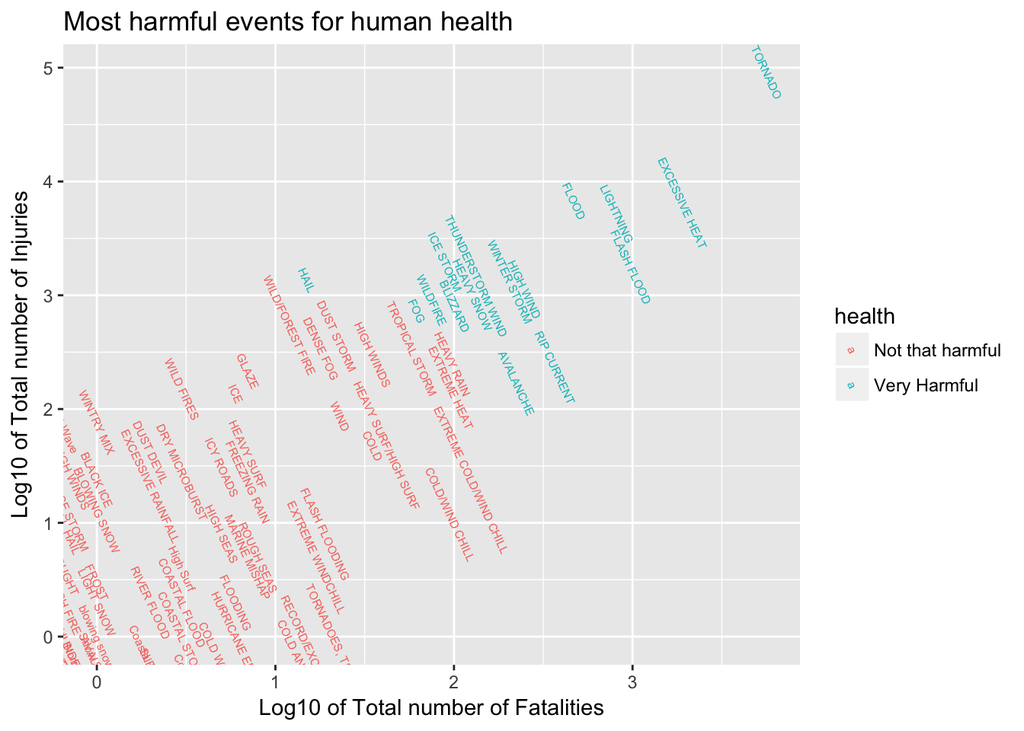

```r
ggplot(dataset1, aes(log10(FATALITIES),log10(INJURIES), label = EVTYPE,color = health)) + geom_text(check_overlap = TRUE,size = 2,angle = -65) +labs(title="Most harmful events for human health", x="Log10 of Total number of Fatalities", y="Log10 of Total number of Injuries")
```

The following list shows the 10 most harmful events in the United States organized in descending order first by the total number of Fatalities and then by the number of injuries.

```r
filter(dataset1,health == "Very Harmful") %>% arrange(desc(FATALITIES),desc(INJURIES))
```

```
## # A tibble: 21 x 4
##            EVTYPE FATALITIES INJURIES       health
##             <chr>      <dbl>    <dbl>        <chr>
##  1        TORNADO       5633    91346 Very Harmful
##  2 EXCESSIVE HEAT       1903     6525 Very Harmful
##  3    FLASH FLOOD        978     1777 Very Harmful
##  4           HEAT        937     2100 Very Harmful
##  5      LIGHTNING        816     5230 Very Harmful
##  6      TSTM WIND        504     6957 Very Harmful
##  7          FLOOD        470     6789 Very Harmful
##  8    RIP CURRENT        368      232 Very Harmful
##  9      HIGH WIND        248     1137 Very Harmful
## 10      AVALANCHE        224      170 Very Harmful
## # ... with 11 more rows
```

On the other hand, to apreciate the most harmful type of events in terms of property damage, the next plot shows the type of events classified by our categorical variable. Unlike before the most harmfull are in the upper part of the plot. In this case we used as xy coordinates the logarithms of the total Property damage and the total damage (property + crop) respectively.

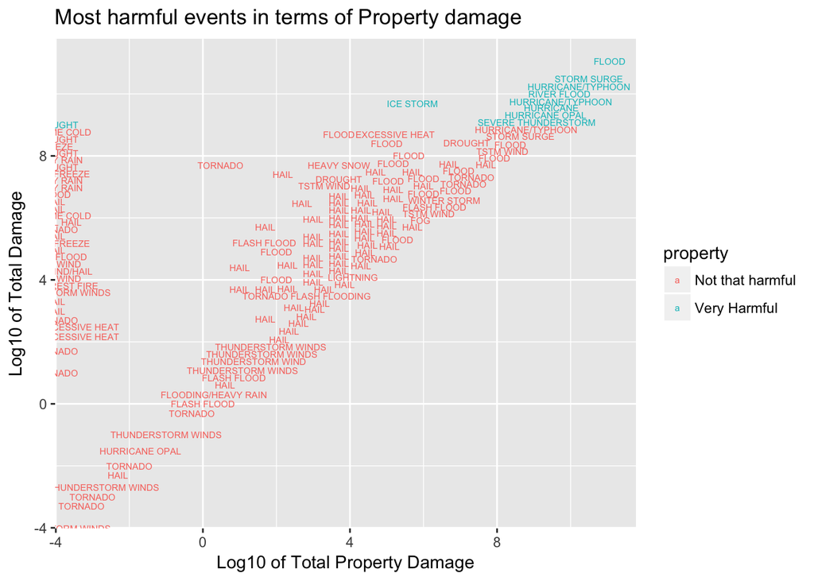

```r
ggplot(dataset2,aes(log10(PROPDMG),log10(TOTALDMG),label = EVTYPE,color=property)) + geom_text(check_overlap = TRUE,size = 2) + labs(title="Most harmful events in terms of Property damage",x = "Log10 of Total Property Damage",y = "Log10 of Total Damage")
```

```r
filter(dataset2,property == "Very Harmful")
```

```
## # A tibble: 42 x 5
##               EVTYPE   PROPDMG  CROPDMG     TOTALDMG     property
##                <chr>     <dbl>    <dbl>        <dbl>        <chr>
##  1             FLOOD 1.150e+11 3.25e+07 115032500000 Very Harmful
##  2       STORM SURGE 3.130e+10 0.00e+00  31300000000 Very Harmful
##  3 HURRICANE/TYPHOON 1.693e+10 0.00e+00  16930000000 Very Harmful
##  4       STORM SURGE 1.126e+10 0.00e+00  11260000000 Very Harmful
##  5       RIVER FLOOD 5.000e+09 5.00e+09  10000000000 Very Harmful
##  6 HURRICANE/TYPHOON 1.000e+10 0.00e+00  10000000000 Very Harmful
##  7 HURRICANE/TYPHOON 5.880e+09 1.51e+09   7390000000 Very Harmful
##  8 HURRICANE/TYPHOON 7.350e+09 0.00e+00   7350000000 Very Harmful
##  9 HURRICANE/TYPHOON 5.420e+09 2.85e+08   5705000000 Very Harmful
## 10    TROPICAL STORM 5.150e+09 0.00e+00   5150000000 Very Harmful
## # ... with 32 more rows
```